# Beta_Example

Ying Zhang

2025-06-12

### Today’s task

- We look into the example of beta prior distribution Beta($\alpha, \beta$) and Binomial model M ~ $p(y|\theta)$.
- We first collect $\theta$ from the our prior distribution and then we generate our data based on our model M
- Then for each y that we generate it, we find all the $\theta$ corresponding to different y.
- Calculate its expectation $E(\theta|y)$ and variance $Var(\theta|y)$
- Use Gausssian distribution to describe the posterior distribution of $p(\theta|y)$

### Compare the true posterior distribution with our approximated distribution

First we select $\theta$ from the prir beta($\alpha, \beta$) with $\alpha = 3$ and $\beta = 3$, and we assume that we observe y = 80 and N = 100. In this case , we can draw the true posterior directly with its posterior distribution to be

$\theta|y$ ~ $Beta(\alpha',\beta')$ with $\alpha' = \alpha +y$ and $\beta' = \beta +n -y$

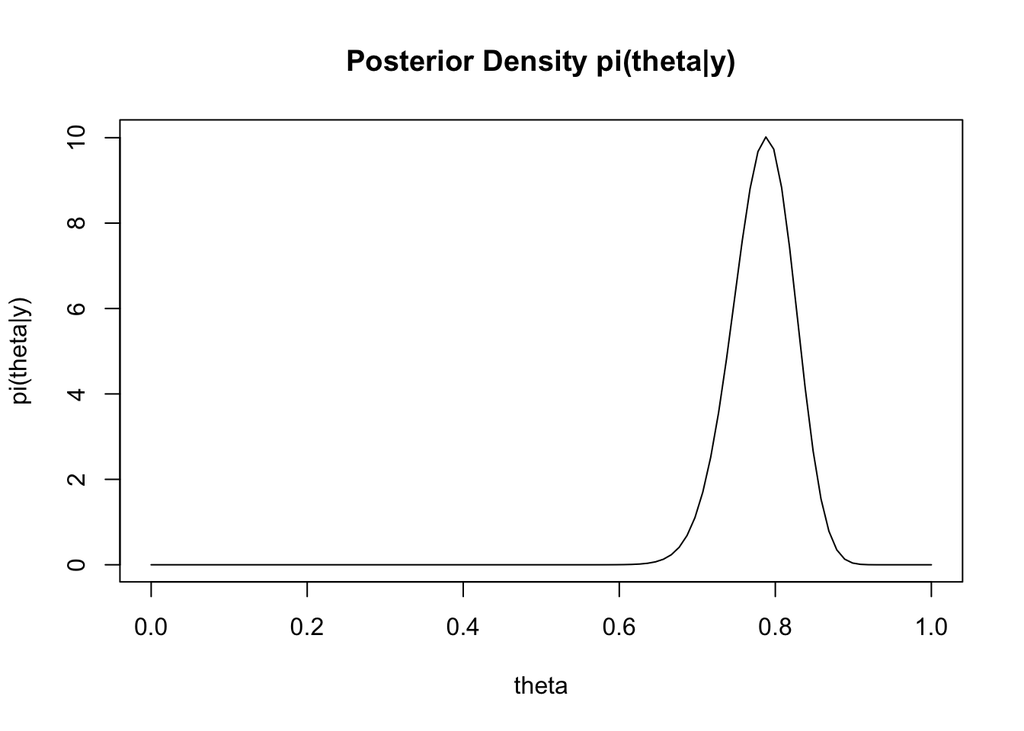

Then we generate the corresponding y based on each collection of $\theta$, in total we generate M pairs of $(\theta_j,y_j$, here we use M = 10^6.

Then for each y, we find all the $\theta$ corresponding to different y and calculate its mean, variance and standard deviation.

After doing that, we plot the Normal distribution using post.mean and post.var for index i = 2.

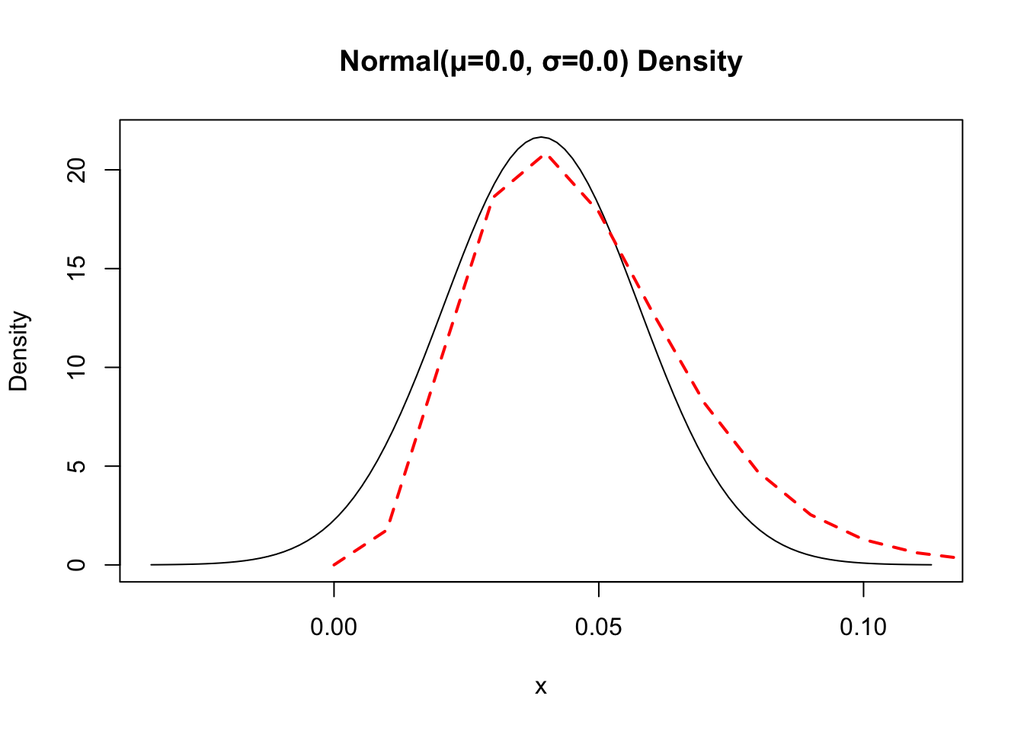

### Find relationship between mean and data y, variance and data y

We First plot mean vs y and we notice that it is linear. We can estimate it with simple linear regression model.

```
##
## Call:
## lm(formula = post.mean.theta.vec ~ v)
##
## Coefficients:
## (Intercept)            v
##    0.028315     0.009434
```

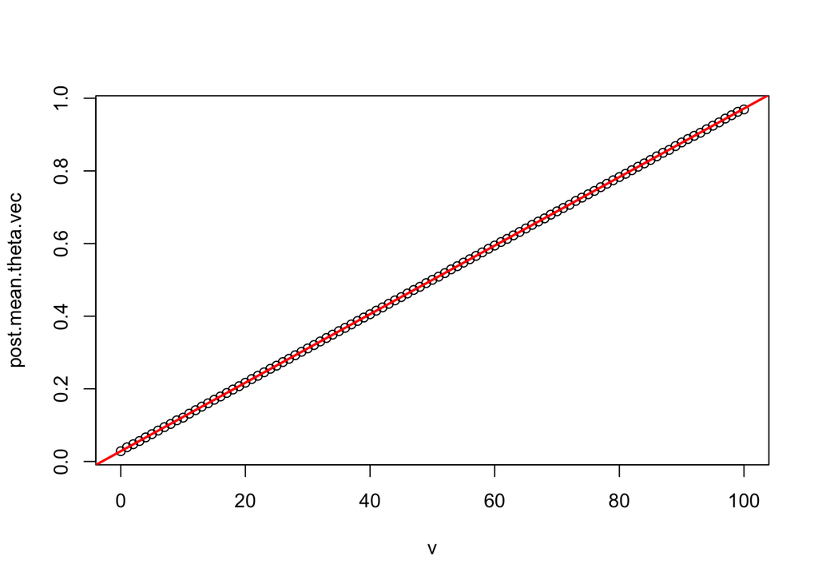

```
##
## Call:
## lm(formula = post.mean.theta.vec ~ v)
##
## Residuals:
##        Min         1Q     Median         3Q        Max
## -2.529e-03 -2.695e-04  5.038e-05  2.977e-04  1.385e-03
##
## Coefficients:
##              Estimate Std. Error t value Pr(>|t|)
## (Intercept) 2.831e-02  9.977e-05   283.8   <2e-16 ***
## v           9.434e-03  1.724e-06  5473.0   <2e-16 ***
## ---
## Signif. codes:  0 '***' 0.001 '**' 0.01 '*' 0.05 '.' 0.1 ' ' 1
##
## Residual standard error: 0.0005051 on 99 degrees of freedom
## Multiple R-squared:      1,  Adjusted R-squared:      1
## F-statistic: 2.995e+07 on 1 and 99 DF,  p-value: < 2.2e-16
```

The figure shows that our linear model fits well.

Then we plot the variance vs y , it shows that there exists quadratic pattern between variance and y , so we try the linear model with lm(post.var.theta.vec ~ v+ I(v^2)), and it fits well as shown below.

```
##
## Call:
## lm(formula = post.var.theta.vec ~ v + I(v^2))
##
## Residuals:
##        Min         1Q     Median         3Q        Max
## -5.389e-05 -1.423e-05  4.110e-07  1.555e-05  8.305e-05
##
## Coefficients:
##               Estimate Std. Error t value Pr(>|t|)
## (Intercept)  2.397e-04  7.245e-06   33.08   <2e-16 ***
## v            8.391e-05  3.348e-07  250.58   <2e-16 ***
## I(v^2)      -8.384e-07  3.240e-09 -258.74   <2e-16 ***
## ---
## Signif. codes:  0 '***' 0.001 '**' 0.01 '*' 0.05 '.' 0.1 ' ' 1
##
## Residual standard error: 2.475e-05 on 98 degrees of freedom
## Multiple R-squared:  0.9985, Adjusted R-squared:  0.9985
## F-statistic: 3.347e+04 on 2 and 98 DF,  p-value: < 2.2e-16
```

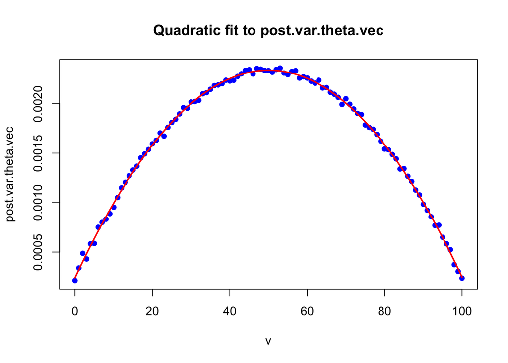